# Illicit Drug Use and Serious Mental Illnesses

Pedro Gallardo Nascimento

2024-12-16

## Introduction

Drug use is a significant issue worldwide — one that has raised extensive scientific inquiry into its implications for individuals and society. This analysis aims to explore the potential connection between illicit drug use and serious mental health illnesses, with a particular focus on whether drug use impacts mental health outcomes. Specifically, this study addresses the question: “What is the relationship between illicit drug use, including marijuana use, and serious mental health disorders across different U.S. states?”

This topic is worth investigating due to the widespread prevalence of drug use and its documented association with various health and societal challenges. Previous research has highlighted correlations between substance use and mental health disorders. For example, Cotto et al. (2010) examined gender differences in substance abuse and dependence using data from the National Survey on Drug Use and Health (NSDUH), finding significant variations in substance use patterns by age and gender. Their findings emphasize the complex relationship between demographic factors and drug use behaviors, underscoring the importance of targeted prevention and treatment interventions. Building on these insights, this analysis investigates the broader relationship between drug use—both overall illicit drug use and marijuana use—and serious mental health illnesses across different geographic regions. This approach helps to address gaps in understanding how these dynamics may vary by state in the United States.

The report is structured as follows: it first provides an overview of the data and methods used, followed by an exploration of key variables and statistical findings. The report concludes with a discussion of the implications, limitations, and potential areas for further research.

## Data Exploration and Explanation

The dataset used for this analysis is derived from the National Survey on Drug Use and Health (NSDUH), an annual survey that collects comprehensive data on substance use and mental health among individuals aged 12 and older in the United States. The data includes statistics on illicit drug use and mental health disorders across various U.S. states, with a focus on the years 2021 and 2022. To ensure accuracy and representativeness, the data is stratified based on key characteristics such as region (e.g., states, U.S. regions, and total U.S.) and age groups (e.g., 12+, 12-17, 18-25). The data is self-reported, and individuals are randomly selected from these strata to participate, ensuring that the dataset reflects the broader U.S. population.

#### Key Variables and Data Cleaning/Transformation

The key variables in the dataset focus on specific topics across various tables. For this analysis, I selected the tables related to illicit drug use in the last month, marijuana use in the last month, attempted suicide rates in the past year, and serious mental health issues in the past year, all broken down by age group and state/region. The key variables include:

- **State**: The U.S. state (e.g., California, Texas), region (e.g., Midwest), or total U.S..
- **Age Group**: Age groups such as 12-17, 18-25, 26+, and 18+.
- **Estimates**: The percentage estimates for each table in each year. Examples:
  - `12+ Estimate`
  - `18+ Estimate`
  - `12-17 Estimate`, etc.
- **Confidence Intervals**: The lower and upper bounds of the confidence interval for each estimate, such as:
  - `12+ 95% CI (Lower)`
  - `12+ 95% CI (Upper)`.

#### Units and Data Types

| Variable | Unit/Type |
| --- | --- |
| **State** | Categorical (Character) |
| **Age Group** | Categorical (Factor) |
| **Estimates** | Numeric (Percentage) |
| **Confidence Intervals** | Numeric (Percentage) |

#### Data Cleaning and Transformations

The following steps were performed to clean and standardize the dataset:

1. Removed the first few rows of the original dataset, as they contained metadata and irrelevant notes rather than data.
2. Set the first row as column names to standardize the dataset.
3. Removed unnecessary columns (such as `Order`) that did not contribute to the analysis.
4. Removed the percentage sign (`%`) from relevant columns and converted the data to numeric type for analysis.

Interestingly, no missing values (NA) were encountered during the cleaning process.

#### Ethical Considerations

When working with datasets derived from self-reported surveys, privacy and bias are important ethical considerations. The dataset used in this analysis is based on self-reported data, which raises concerns about the privacy of individuals. The survey covers sensitive topics like substance use and mental health, so it is essential that the data be anonymized to protect participants’ identities. In the case of the NSDUH, personal identifiers have been removed, and the data is aggregated to prevent identification. However, care must still be taken when interpreting the data to ensure that no sensitive information is inadvertently revealed.

Bias is another concern. Although the NSDUH strives to be representative of the U.S. population, biases can still be present. Response bias may happen if certain individuals are less likely to participate due to the sensitive nature of the questions, potentially leading to underreporting of behaviors like illicit drug use or mental health issues. On top of that, self-reporting can introduce inaccuracies, due to the fact that respondents may not always provide truthful answers due to social desirability bias or memory recall issues. Even though the dataset is stratified by region and age group, there may still be underrepresentation of certain populations, such as those who are homeless or institutionalized. These biases must be considered when analyzing and interpreting the data, since they have the potential to impact the conclusions drawn from the findings.

#### Summary Statistics

```r
summary_stats <- table_1_cleaned %>%
  select(`12+ Estimate`, `12+ 95% CI (Lower)`, `12+ 95% CI (Upper)`) %>%
  summary()

summary_stats
```

```
##   12+ Estimate   12+ 95% CI (Lower) 12+ 95% CI (Upper)
##  Min.   :10.28   Min.   : 9.14      Min.   :11.38
##  1st Qu.:12.71   1st Qu.:10.96      1st Qu.:14.82
##  Median :15.84   Median :13.86      Median :17.75
##  Mean   :16.18   Mean   :14.14      Mean   :18.46
##  3rd Qu.:18.83   3rd Qu.:16.66      3rd Qu.:21.09
##  Max.   :26.16   Max.   :23.18      Max.   :29.39
```

For Illicit Drug Use in the Past Month (12+ Estimate) across different states, regions, and the total U.S., the data shows notable variability. The mean estimate for illicit drug use is approximately 16.18%, with a median of 15.84%, suggesting a slightly higher average than the middle value. The estimates range from a minimum of 10.28% to a maximum of 26.16%, indicating a significant disparity in drug use across regions. The 95% confidence intervals further reflect this variability. The lower bound ranges from 9.14% to 23.18%, while the upper bound ranges from 11.38% to 29.39%. This wide range of confidence intervals suggests that the data can be quite variable, and in some cases, the ranking of states with higher drug use could be uncertain, as confidence intervals may overlap or shift. Thus, this summary highlights the variation in drug use rates across states, with some states showing significantly higher estimates, while others may experience fluctuations in the interpretation due to the wide confidence intervals.

```r
summary_stats <- table_32_cleaned %>%
  select(`18+ Estimate`, `18+ 95% CI (Lower)`, `18+ 95% CI (Upper)`) %>%
  summary()

summary_stats
```

```
##   18+ Estimate   18+ 95% CI (Lower) 18+ 95% CI (Upper)
##  Min.   :5.050   Min.   :4.200      Min.   :5.910
##  1st Qu.:5.657   1st Qu.:4.810      1st Qu.:6.577
##  Median :6.110   Median :5.095      Median :7.255
##  Mean   :6.137   Mean   :5.135      Mean   :7.330
##  3rd Qu.:6.518   3rd Qu.:5.515      3rd Qu.:7.933
##  Max.   :8.020   Max.   :6.790      Max.   :9.440
```

The 18+ Estimate for serious mental health issues in the past year among individuals aged 18 and older across states has a mean of 6.14%, with a median of 6.11%, indicating a relatively balanced distribution. The estimates range from a minimum of 5.05% to a maximum of 8.02%, showing variability in the prevalence of serious mental health issues across states. The 95% confidence intervals also demonstrate a considerable spread: the lower bounds range from 4.20% to 6.79%, and the upper bounds range from 5.91% to 9.44%. This variability emphasizes differences in mental health issues across states, with some regions reporting significantly higher or lower estimates. However, this distribution appears more consistent compared to the drug use estimates.

#### Visualizations

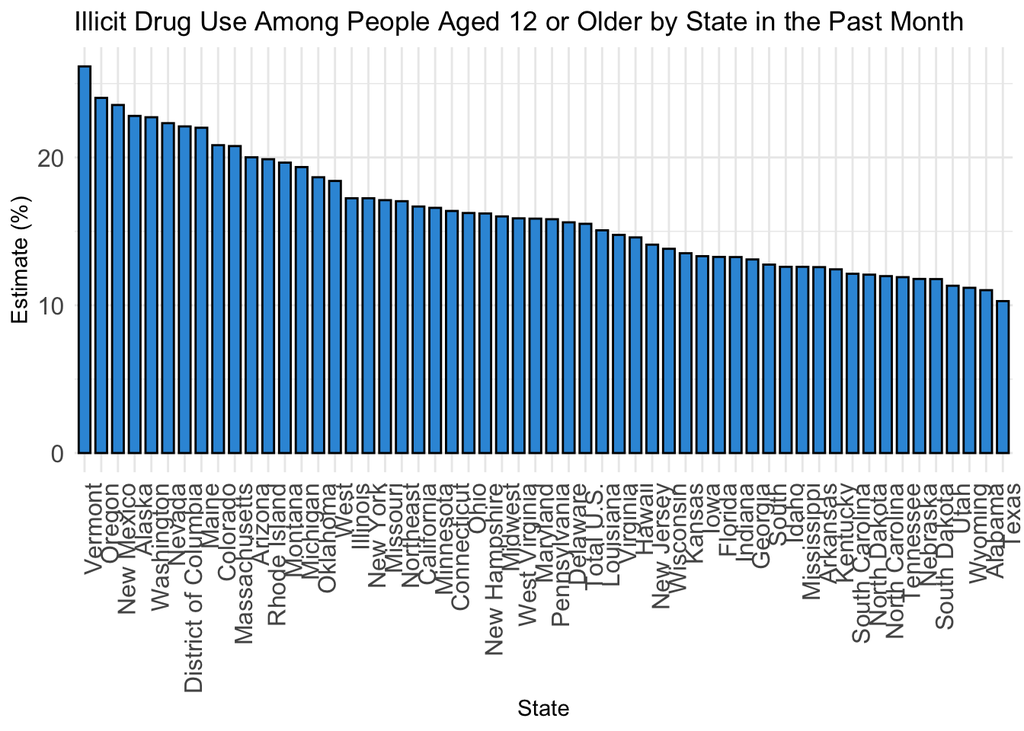

```r
# Plotting the data of table 1 in descending order of 12+ Estimate
ggplot(table_1_cleaned, aes(x = reorder(State, `12+ Estimate`, FUN = desc), y = `12+ Estimate`)) +
  geom_bar(stat = "identity", fill = "#3498db", color = "black", width = 0.7) +
  labs(
    title = "Illicit Drug Use Among People Aged 12 or Older by State in the Past Month",
    x = "State",
    y = "Estimate (%)"
  ) +
  theme_minimal() +
  theme(
    axis.text.x = element_text(angle = 90, hjust = 1, size = 12, color = "#555555"),
    axis.text.y = element_text(size = 12, color = "#555555")
  )
```

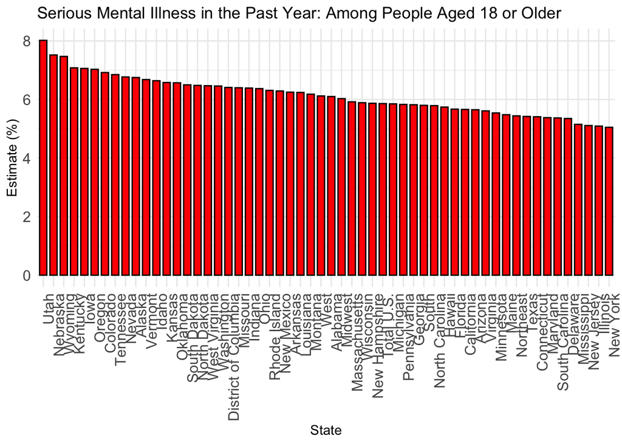

Looking at the Serious Mental Illness (SMI) estimates for individuals aged 18+ across different states, regions, and the total U.S., we observe a clear pattern of low variability across states, indicating greater consistency in the prevalence of serious mental illness. However, when comparing the regions, some states seem to shift positions dramatically between the two graphs. For example, Utah ranks first in this graph but is closer to last in the other. On the other hand, some regions, like the Midwest, appear more consistent, with their positions remaining relatively similar across the graphs (closer to the middle). Still, it is difficult to identify a clear pattern from these graphs alone.

## Statistical Analysis and Interpretation

```r
# Run the regression
model <- lm(`18+ Estimate` ~ `18+ Estimate_weed` + `18+ Estimate_drug`, data = combined_data)

# Summary of the model
summary(model)
```

```
##
## Call:
## lm(formula = `18+ Estimate` ~ `18+ Estimate_weed` + `18+ Estimate_drug`,
##     data = combined_data)
##
## Residuals:
##      Min       1Q   Median       3Q      Max
## -0.99637 -0.51242 -0.07148  0.43836  1.78554
##
## Coefficients:
##                     Estimate Std. Error t value Pr(>|t|)
## (Intercept)           5.7179     0.4471  12.787   <2e-16 ***
## `18+ Estimate_weed`  -0.2540     0.1823  -1.393    0.169
## `18+ Estimate_drug`   0.2566     0.1823   1.407    0.165
## ---
## Signif. codes:  0 '***' 0.001 '**' 0.01 '*' 0.05 '.' 0.1 ' ' 1
##
## Residual standard error: 0.6567 on 53 degrees of freedom
## Multiple R-squared:  0.03606,    Adjusted R-squared:  -0.000314
## F-statistic: 0.9914 on 2 and 53 DF,  p-value: 0.3778
```

This analysis begins by utilizing the regression model above, which examines the relationship between the percentage of individuals aged 18 and older with serious mental illness (18+ Estimate) and two predictors: marijuana use (18+ Estimate_weed) and illicit drug use (18+ Estimate_drug) in the past month. The intercept of 5.7179% suggests that when both predictors are zero, the expected percentage of individuals with serious mental illness is 5.7179%, which is statistically significant.

However, the coefficients for marijuana use (-0.2540) and illicit drug use (0.2566) indicate weak relationships with serious mental illness, and their p-values (0.169 and 0.165, respectively) show that these relationships are not statistically significant.

With an R-squared value of 0.03606, the model explains only about 3.6% of the variation in serious mental illness, which suggests that other factors may be more influential. The negative adjusted R-squared value further indicate that the model does not provide a meaningful explanation of the data. These results are expected to be inflated due to the inclusion of two predictors, so it would be more appropriate to analyze them separately.

```r
model_drug <- lm(`18+ Estimate` ~ `18+ Estimate_drug`, data = combined_data)
summary(model_drug)
```

```
##
## Call:
## lm(formula = `18+ Estimate` ~ `18+ Estimate_drug`, data = combined_data)
##
## Residuals:
##      Min       1Q   Median       3Q      Max
## -1.09167 -0.48623 -0.02086  0.39239  1.90390
##
## Coefficients:
##                     Estimate Std. Error t value Pr(>|t|)
## (Intercept)         6.062719   0.375586  16.142   <2e-16 ***
## `18+ Estimate_drug` 0.004386   0.021460   0.204    0.839
## ---
## Signif. codes:  0 '***' 0.001 '**' 0.01 '*' 0.05 '.' 0.1 ' ' 1
##
## Residual standard error: 0.6624 on 54 degrees of freedom
## Multiple R-squared:  0.000773,   Adjusted R-squared:  -0.01773
## F-statistic: 0.04177 on 1 and 54 DF,  p-value: 0.8388
```

```r
model_weed <- lm(`18+ Estimate` ~ `18+ Estimate_weed`, data = combined_data)
summary(model_weed)
```

```
##
## Call:
## lm(formula = `18+ Estimate` ~ `18+ Estimate_weed`, data = combined_data)
##
## Residuals:
##      Min       1Q   Median       3Q      Max
## -1.08854 -0.48116 -0.02546  0.38218  1.88741
##
## Coefficients:
##                      Estimate Std. Error t value Pr(>|t|)
## (Intercept)         6.1233823  0.3450453  17.747   <2e-16 ***
## `18+ Estimate_weed` 0.0008975  0.0214734   0.042    0.967
## ---
## Signif. codes:  0 '***' 0.001 '**' 0.01 '*' 0.05 '.' 0.1 ' ' 1
##
## Residual standard error: 0.6626 on 54 degrees of freedom
## Multiple R-squared:  3.235e-05,  Adjusted R-squared:  -0.01849
## F-statistic: 0.001747 on 1 and 54 DF,  p-value: 0.9668
```

The regression analysis examining the relationship between illicit drug use (in the past month) and serious mental illness (in the past year) among individuals aged 18+ shows weak results. The intercept value of 6.062719% suggests that, in the absence of illicit drug use, the expected percentage of individuals with serious mental illness is around 6.062719%. The coefficient for illicit drug use is 0.004386, indicating a very slight positive relationship with serious mental illness, but with a p-value of 0.839, this result is not statistically significant. This means there’s no strong evidence to suggest illicit drug use has a meaningful impact on the prevalence of serious mental illness.

The R-squared value of 0.000773 shows that illicit drug use explains almost none of the variation in serious mental illness rates, and the negative adjusted R-squared value of -0.01773 suggests the model doesn’t improve upon a simple average model. With a p-value of 0.839, the model as a whole is not statistically significant.

In a similar fashion, when looking at marijuana use separately, the regression analysis shows no significant relationship with serious mental health issues. The coefficient for marijuana use is close to 0.0009, with a p-value of 0.967, meaning marijuana use doesn’t significantly predict the mental health estimates. The adjusted R-squared value is close to zero, further indicating that marijuana use doesn’t explain much of the variation in serious mental illness estimates. Overall, this analysis suggests that neither illicit drug use nor marijuana use has a significant impact on serious mental health estimates in this dataset.

```r
model_suicide <- lm(`18+ Estimate_suicide` ~ `18+ Estimate_weed` + `18+ Estimate_drug` + `18+ Estimate`, data = combined_data)
summary(model_suicide)
```

```
##
## Call:
## lm(formula = `18+ Estimate_suicide` ~ `18+ Estimate_weed` + `18+ Estimate_drug` +
##     `18+ Estimate`, data = combined_data)
##
## Residuals:
##       Min        1Q    Median        3Q       Max
## -0.145714 -0.035044  0.000822  0.033735  0.157380
##
## Coefficients:
##                     Estimate Std. Error t value Pr(>|t|)
## (Intercept)          0.39835    0.09110   4.373 5.91e-05 ***
## `18+ Estimate_weed`  0.03660    0.01871   1.956   0.0558 .
## `18+ Estimate_drug` -0.03864    0.01871  -2.065   0.0439 *
## `18+ Estimate`       0.06185    0.01385   4.467 4.30e-05 ***
## ---
## Signif. codes:  0 '***' 0.001 '**' 0.01 '*' 0.05 '.' 0.1 ' ' 1
##
## Residual standard error: 0.06619 on 52 degrees of freedom
## Multiple R-squared:  0.2987, Adjusted R-squared:  0.2582
## F-statistic: 7.382 on 3 and 52 DF,  p-value: 0.0003276
```

## Conclusion

Using the NSDUH data, this analysis found no clear correlation between illicit drug use, marijuana use in the past month, and serious mental health issues. Although some correlations were observed with suicide rates, those related to illicit drug use and marijuana use were weak. Therefore, it is not possible to definitively conclude that these factors influence each other based on this data alone. Limitations of this study include the reliance on self-reported data, which may be subject to biases, as well as the fact that we only explored a limited set of variables. The weak correlations suggest that there may be other factors at play that were not captured in this analysis.

Next steps for future research should focus on incorporating additional variables, such as socioeconomic status, personality traits, and other mental health indicators, which could provide stronger insights into the factors contributing to serious mental health issues and suicide, or drug use and marijuana use. Expanding the scope of the data used could lead to a more comprehensive understanding. Ethical considerations are also important to note. Given the sensitive nature of mental health and substance use data, it is essential to ensure privacy and confidentiality in handling such data. Furthermore, researchers must be mindful of the potential harm in overgeneralizing results or making conclusions that could stigmatize certain populations. It is crucial that findings are communicated with care and respect for those affected by these issues.

## References

Substance Abuse and Mental Health Services Administration. (2022). State reports: National Survey on Drug Use and Health (NSDUH) 2022. https://www.samhsa.gov/data/nsduh/state-reports-NSDUH-2022

Cotto, J. H., Davis, E., Dowling, G. J., Elcano, J. C., Staton, A. B., & Weiss, S. R. B. (2010). Gender effects on drug use, abuse, and dependence: A special analysis of results from the National Survey on Drug Use and Health. Gender Medicine, 7(5), 402-413. https://doi.org/10.1016/j.genm.2010.09.004